# Coupon redemption propensity

Guiding Question: Who to target (Coupon redemption propensity)

## Data & headline metrics

```python
from pathlib import Path
import sys

import numpy as np
import pandas as pd
import seaborn as sns
import matplotlib.pyplot as plt

sns.set_theme(style="whitegrid", context="talk")
plt.rcParams["figure.figsize"] = (8, 5)

project_dir = Path.cwd()
repo_root = project_dir.parent.parent
raw_data_dir = repo_root / "innitial_datasets"

if str(project_dir) not in sys.path:
    sys.path.append(str(project_dir))

from functions import (
    build_campaign_level_dataset,
    get_feature_target_split,
    train_logistic_model,
    evaluate_classification_model,
    compute_lift_table,
    plot_confusion_matrix,
    plot_roc_curve,
    plot_lift_chart,
)
```

```python
compiled_data_path = project_dir / "data" / "coupon_campaign_dataset.csv"

campaign_df = build_campaign_level_dataset(
    raw_dir=raw_data_dir,
    output_path=compiled_data_path,
)

print(f"Compiled dataset saved to: {compiled_data_path}")
print(f"Rows: {campaign_df.shape[0]}, Columns: {campaign_df.shape[1]}")
campaign_df.head()
```

```
Compiled dataset saved to: /Users/arturrenzenbrink/github/ie_ca/code/d_coupon_redemption_propensity/data/coupon_campaign_dataset.csv
```

|  | campaign_type | household_key | CAMPAIGN | START_DAY | END_DAY | campaign_length_days | campaign_sequence | campaigns_total | days_since_prev_campaign | overlap_with_prev_campaign | ... | coupon_discount_last_180d | avg_basket_value_last_180d | coupon_share_last_180d | classification_1 | classification_2 | classification_3 | classification_4 | classification_5 | HOMEOWNER_DESC | KID_CATEGORY_DESC |
| --- | --- | --- | --- | --- | --- | --- | --- | --- | --- | --- | --- | --- | --- | --- | --- | --- | --- | --- | --- | --- | --- |
| 0 | TypeB | 1 | 29 | 281 | 334 | 54 | 1 | 8 | 281.0 | 0 | ... | 0.0 | 55.290000 | 0.0 | Age Group6 | X | Level4 | 2 | Group5 | Homeowner | None/Unknown |
| 1 | TypeA | 1 | 8 | 412 | 460 | 49 | 2 | 8 | 78.0 | 0 | ... | 0.0 | 49.146818 | 0.0 | Age Group6 | X | Level4 | 2 | Group5 | Homeowner | None/Unknown |
| 2 | TypeB | 1 | 12 | 477 | 509 | 33 | 3 | 8 | 17.0 | 0 | ... | 0.0 | 54.249565 | 0.0 | Age Group6 | X | Level4 | 2 | Group5 | Homeowner | None/Unknown |
| 3 | TypeA | 1 | 13 | 504 | 551 | 48 | 4 | 8 | 0.0 | 1 | ... | 0.0 | 50.982400 | 0.0 | Age Group6 | X | Level4 | 2 | Group5 | Homeowner | None/Unknown |
| 4 | TypeA | 1 | 18 | 587 | 642 | 56 | 5 | 8 | 36.0 | 0 | ... | 0.0 | 44.765385 | 0.0 | Age Group6 | X | Level4 | 2 | Group5 | Homeowner | None/Unknown |

5 rows × 63 columns

We compiled a household campaign dataset directly from the original csv files so the downstream analysis remains reproducible. Negative gaps between consecutive campaigns are clipped to zero and we keep a binary overlap flag so cadence features stay realistic. We also compute campaign-window spend/trips/units so we can compare redemption to in-window spending.

```python
total_households = campaign_df["household_key"].nunique()
total_campaigns = campaign_df["CAMPAIGN"].nunique()
overall_rate = campaign_df["redeemed"].mean()

campaign_type_summary = (
    campaign_df.groupby("campaign_type")["redeemed"]
    .agg(redemption_rate="mean", campaign_observations="count")
    .reset_index()
    .sort_values("redemption_rate", ascending=False)
)

headline_table = pd.DataFrame(
    {
        "metric": ["households", "campaigns", "overall redemption rate"],
        "value": [total_households, total_campaigns, overall_rate],
    }
)

display(headline_table)
display(campaign_type_summary)
```

|  | metric | value |
| --- | --- | --- |
| 0 | households | 1584.000000 |
| 1 | campaigns | 30.000000 |
| 2 | overall redemption rate | 0.123335 |

|  | campaign_type | redemption_rate | campaign_observations |
| --- | --- | --- | --- |
| 0 | TypeA | 0.159588 | 3979 |
| 1 | TypeB | 0.079096 | 2655 |
| 2 | TypeC | 0.076655 | 574 |

We see 1,584 target households with thirty campaigns and an overall redemption rate near twelve percent. TypeA campaigns convert about sixteen percent of households—roughly double the TypeB/TypeC rate—so they are the best coupon templates when budget is limited.

## Shopper behavior before campaigns

```python
behavior_cols = [
    "sales_last_60d",
    "trips_last_60d",
    "coupon_discount_last_60d",
    "days_since_last_purchase",
    "tenure_days",
]

behavior_summary = (
    campaign_df.groupby("redeemed")[behavior_cols]
    .mean()
    .rename(index={0: "No redemption", 1: "Redeemed"})
)
behavior_summary
```

| redeemed | sales_last_60d | trips_last_60d | coupon_discount_last_60d | days_since_last_purchase | tenure_days |
| --- | --- | --- | --- | --- | --- |
| No redemption | 552.845529 | 17.749327 | 0.0 | 6.832885 | 425.391992 |
| Redeemed | 727.628043 | 20.140607 | 0.0 | 4.134983 | 435.902137 |

## Campaign spend impact

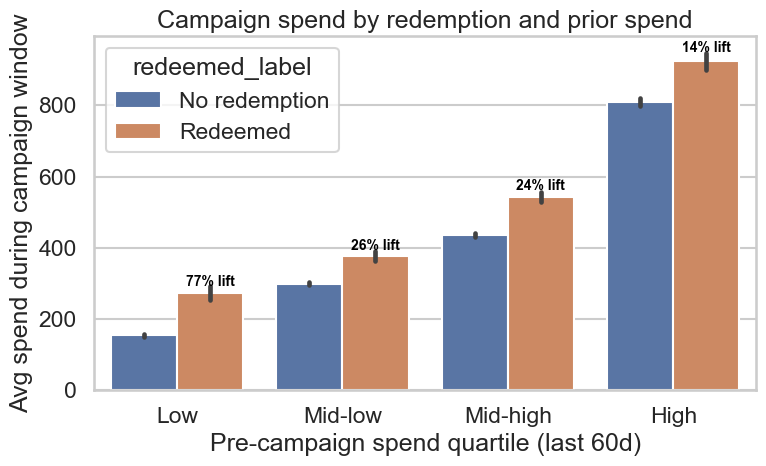

```python
# Campaign spend during the window by redemption status and pre-campaign spend quartile
spend_plot_df = campaign_df.copy()
spend_plot_df["redeemed_label"] = spend_plot_df["redeemed"].map({0: "No redemption", 1: "Redeemed"})
spend_plot_df["pre_spend_quartile"] = pd.qcut(
    spend_plot_df["sales_last_60d"], q=4, labels=["Low", "Mid-low", "Mid-high", "High"]
)

fig, ax = plt.subplots(figsize=(8, 5))
sns.barplot(
    data=spend_plot_df,
    x="pre_spend_quartile",
    y="sales_during_campaign",
    hue="redeemed_label",
    estimator=np.mean,
    errorbar="se",
    ax=ax,
)
ax.set_xlabel("Pre-campaign spend quartile (last 60d)")
ax.set_ylabel("Avg spend during campaign window")
ax.set_title("Campaign spend by redemption and prior spend")

# Annotate % lift of Redeemed vs No redemption for each quartile
means = (
    spend_plot_df.groupby(["pre_spend_quartile", "redeemed_label"])["sales_during_campaign"]
    .mean()
    .unstack()
)
# Use the redeemed bar container to place labels directly over the redeemed bars
bar_containers = ax.containers
if len(bar_containers) >= 2:
    redeemed_bars = bar_containers[1]
    for bar, quart in zip(redeemed_bars, means.index):
        base = means.loc[quart, "No redemption"]
        lift_val = means.loc[quart, "Redeemed"]
        pct_lift = (lift_val / base - 1) * 100 if base > 0 else np.nan
        if np.isfinite(pct_lift):
            x = bar.get_x() + bar.get_width() / 2
            y = bar.get_height()
            ax.text(
                x,
                y + max(y * 0.02, 10),
                f"{pct_lift:.0f}% lift",
                ha="center",
                va="bottom",
                fontsize=10,
                fontweight="bold",
                color="black",
            )

plt.tight_layout()
```

**Business takeaways (spend impact):**

- Redeemers spend more during the campaign window in every pre-spend quartile; lifts range from ~14% (High) to ~77% (Low).
- Absolute dollars still concentrate in Mid-high/High quartiles, so revenue impact is largest there despite lower % lift.
- Low-spend redeemers show the biggest % lift but small dollar gain—good for activation tests, not core revenue. **Recommendation:** Prioritize high-score households in Mid-high/High quartiles for revenue; run small tests on Low quartile high-scorers to see if the % lift translates to meaningful dollars.

## Campaign template performance

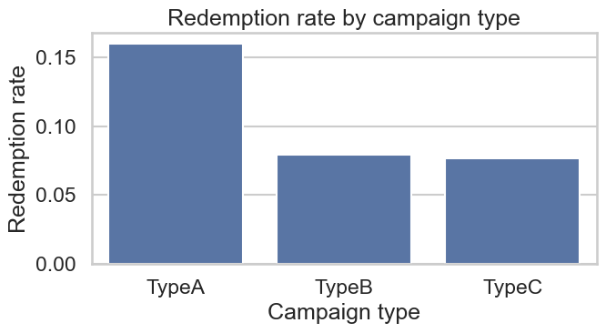

```python
fig, ax = plt.subplots(figsize=(7, 4))
sns.barplot(
    data=campaign_df,
    x="campaign_type",
    y="redeemed",
    estimator=np.mean,
    errorbar=None,
    order=campaign_type_summary["campaign_type"],
    ax=ax,
)
ax.set_ylabel("Redemption rate")
ax.set_xlabel("Campaign type")
ax.set_title("Redemption rate by campaign type")
plt.tight_layout()
```

**Business takeaways (campaign types):**

- TypeA delivers the highest redemption rate among templates.
- TypeB and TypeC trail TypeA, so they are secondary choices when budgets are limited.
- Differences across types suggest the offer template matters nearly as much as audience quality. **Recommendation:** Fund TypeA campaigns first, then allocate remaining budget to the top-scoring households in TypeB/TypeC.

## Spend distribution by redemption

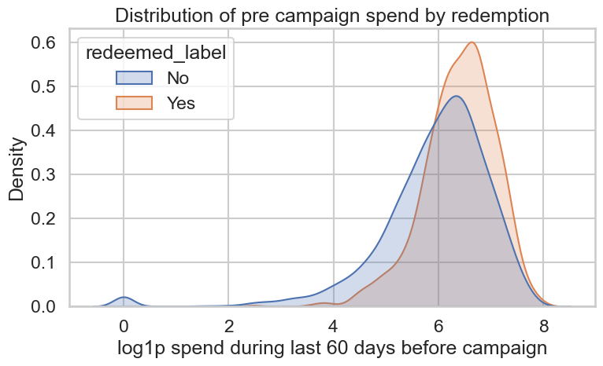

```python
plot_df = campaign_df.assign(
    redeemed_label=campaign_df["redeemed"].map({0: "No", 1: "Yes"})
)
plot_df["log_sales_last_60d"] = np.log1p(plot_df["sales_last_60d"])

fig, ax = plt.subplots(figsize=(8, 5))
sns.kdeplot(
    data=plot_df,
    x="log_sales_last_60d",
    hue="redeemed_label",
    fill=True,
    common_norm=False,
    ax=ax,
)
ax.set_xlabel("log1p spend during last 60 days before campaign")
ax.set_ylabel("Density")
ax.set_title("Distribution of pre campaign spend by redemption")
plt.tight_layout()
```

**Business takeaways (spend distribution):**

- Redeemers cluster at higher pre-campaign spend levels.
- There is a clear shift right for redeemers, confirming that recent spend is a strong signal.
- Lower-spend households redeem less frequently, so rank ordering by spend-linked features is valuable. **Recommendation:** Prioritize higher recent spenders in the score ranking for coupon allocation.